# a

a

2022-09-21

### 1) Un investigador considera tres índices para medir la severidad de los ataques al corazón. Los valores de esos índices para n = 40 pacientes con ataque al corazón que llegan a las emergencias de un hospital producen las siguientes estadísticas resumidas

```r
n = 40
q = 3
xbar = rbind(46.1, 57.3, 50.4)
S = rbind(c(101.3, 63.0, 71.0), c(63.0, 80.2, 55.6), c(71.0, 55.6, 97.4))
xbar
```

```
##      [,1]
## [1,] 46.1
## [2,] 57.3
## [3,] 50.4
```

```r
S
```

```
##       [,1] [,2] [,3]
## [1,] 101.3 63.0 71.0
## [2,]  63.0 80.2 55.6
## [3,]  71.0 55.6 97.4
```

**a) Los tres índices son evaluados para cada paciente. Realice una prueba para la igualdad de las medias de los índices con $\alpha = 0.05$.**

```r
C = rbind(c(1,-1,0), c(1,0,-1))
mmuestr = C%*%xbar
covmuestr = C%*%S%*%t(C)
Tcuadrado = n*t(mmuestr)%*%solve(covmuestr)%*%mmuestr
f = ((n-1)*(q-1)/(n-q+1))*qf(p=1-.05, df1=q-1, df2=n-q+1)
f
```

```
## [1] 6.660417
```

```r
Tcuadrado
```

```
##          [,1]
## [1,] 90.49458
```

Como el valor de $T^2$ es mucho mayor que el de $F$, se rechaza la hipótesis de que las medias sean iguales.

**b) Juzgue las diferencias entre pares de las medias de los índices usando intervalos de confianza ($T^2$) simultaneos del 95%.**

```r
#Intervalos de confianza mu1-mu2
uint1conf = t(C[1,])%*%xbar+sqrt(f)*sqrt(C[1,]%*%S%*%C[1,]/n)
lint1conf = t(C[1,])%*%xbar-sqrt(f)*sqrt(C[1,]%*%S%*%C[1,]/n)
x1_x2 = xbar[1]-xbar[2]
#Mostrar los intervalos1
print(c(lint1conf,uint1conf))
```

```
## [1] -14.239955  -8.160045
```

```r
#Intervalos de confianza mu1-mu3
uint2conf = t(C[2,])%*%xbar+sqrt(f)*sqrt(C[2,]%*%S%*%C[2,]/n)
lint2conf = t(C[2,])%*%xbar-sqrt(f)*sqrt(C[2,]%*%S%*%C[2,]/n)
x1_x3 = xbar[1]-xbar[3]
#MOstrar los intervalos2
print(c(lint2conf,uint2conf))
```

```
## [1] -7.372644 -1.227356
```

```r
#Intervalos de confianza mu2-mu3
uint3conf = t(c(0,1,-1))%*%xbar+sqrt(f)*sqrt(c(0,1,-1)%*%S%*%c(0,1,-1)/n)
lint3conf = t(c(0,1,-1))%*%xbar-sqrt(f)*sqrt(c(0,1,-1)%*%S%*%c(0,1,-1)/n)
x2_x3 = xbar[2]-xbar[3]
#MOstrar los intervalos3
print(c(lint3conf,uint3conf))
```

```
## [1]  3.5749 10.2251
```

El 0 no cae en ninguno de los intervalos entonces es evidente que si hay diferencia entre las medias, luego reafirmamos la decisión de rechazar $H_0$.

###2) Observaciones sobre dos respuestas fueron coleccionadas para dos tratamientos. Las observaciones vectoriales $[x_1,x_2]$ fueron

```r
trat21 = rbind(3,3)
trat22 = rbind(1,6)
trat23 = rbind(2,3)
trat31 = rbind(2,3)
trat32 = rbind(5,1)
trat33 = rbind(3,1)
trat34 = rbind(2,3)
```

**a) Calcule $S_{pooled}$**

```r
trat2 = cbind(trat21,trat22,trat23)
trat3 = cbind(trat31,trat32,trat33,trat34)
n2 = 3
n3 = 4
p = 2
S2 = cov(t(trat2))
S3 = cov(t(trat3))
x2bar = (1/n2)*(trat21+trat22+trat23)
x3bar = (1/n3)*(trat31+trat32+trat33+trat34)
Spooled = ((n2-1)*S2+(n3-1)*S3)/(n2+n3-2)
Spooled
```

```
##      [,1] [,2]
## [1,]  1.6 -1.4
## [2,] -1.4  2.0
```

**b) Realice la prueba $H_0$: $\mu_2-\mu_3 = 0$ usando un enfoque de dos muestras con $\alpha=.01$.**

```r
T2 = t(x2bar-x3bar)%*%solve(((1/n2)+(1/n3))*Spooled)%*%(x2bar-x3bar)
f = ((n2+n3-2)*p/(n2+n3-p-1))*qf(p=0.01, df1=p, df2=n2+n3-p-1, lower.tail = FALSE)
f
```

```
## [1] 45
```

```r
T2
```

```
##          [,1]
## [1,] 3.870968
```

Con estos resultados, no se recahza $H_0$ con una confianza de $\alpha = 0.01$, luego es posible que haya una igualdad de medias.

**c) Construya un intervalo de confianza simultaneo ($T^2$) del 99% para las diferencias $\mu_{2i} = \mu_{3i}$, $i=1,2$.**

```r
#Intervalo para i=1
uint1conf = (x2bar[1]-x3bar[1])+sqrt(T2)*sqrt(((1/n2)+(1/n3))*Spooled[1,1])
lint1conf = (x2bar[1]-x3bar[1])-sqrt(T2)*sqrt(((1/n2)+(1/n3))*Spooled[1,1])
print(c(lint1conf,uint1conf))
```

```
## [1] -2.9007639  0.9007639
```

```r
#Intervalo para i=2
uint2conf = (x2bar[2]-x3bar[2])+sqrt(T2)*sqrt(((1/n2)+(1/n3))*Spooled[2,2])
lint2conf = (x2bar[2]-x3bar[2])-sqrt(T2)*sqrt(((1/n2)+(1/n3))*Spooled[2,2])
print(c(lint2conf,uint2conf))
```

```
## [1] -0.1251186  4.1251186
```

Como el valor 0 se encuentra en ambos intervalos, si es posible que haya igualdad de medias, como tambien vimos con la prueba de hipotesis.

### 3) Dados los datos

```r
z1 = rbind(10,5,7,19,11,18)
z2 = rbind(2,3,3,6,7,9)
y = rbind(15,9,3,25,7,13)
```

**a) ajuste el modelo de regresion lineal.**

```r
model = lm(as.numeric(y)~as.numeric(z1)+as.numeric(z2))
summary(model)
```

```
##
## Call:
## lm(formula = as.numeric(y) ~ as.numeric(z1) + as.numeric(z2))
##
## Residuals:
##       1       2       3       4       5       6
## -0.5945  4.5054 -5.0592  2.1180  0.5649 -1.5347
##
## Coefficients:
##                Estimate Std. Error t value Pr(>|t|)
## (Intercept)      2.1480     4.2967   0.500   0.6515
## as.numeric(z1)   1.7823     0.4982   3.578   0.0374 *
## as.numeric(z2)  -2.1883     1.0329  -2.119   0.1243
## ---
## Signif. codes:  0 '***' 0.001 '**' 0.01 '*' 0.05 '.' 0.1 ' ' 1
##
## Residual standard error: 4.219 on 3 degrees of freedom
## Multiple R-squared:  0.8183, Adjusted R-squared:  0.6972
## F-statistic: 6.757 on 2 and 3 DF,  p-value: 0.07743
```

**b) Determine los intervalos de confianza del 95% simultaneos (uno a la vez) para $\beta_1$ y $\beta_2$.**

```r
confint.lm(model)
```

```
##                      2.5 %    97.5 %
## (Intercept)    -11.5259154 15.821867
## as.numeric(z1)   0.1968411  3.367791
## as.numeric(z2)  -5.4753736  1.098707
```

Los intervalos de confianza para $\beta_1$ son aquellos relacionados a z1 y los de $\beta_2$ los de z2.

**c) Compruebe la prueba de hipotesis nula de que solo el coeficiente $\beta_1$ es cero.**

Teniendo en cuenta que el p-valor para $\beta_1$ es de 0.0374 y que ademas en el intervalo de confianza no se encuentra el valor 0, se puede rechazar la hipotesis nula y asi decir que $\beta_1$ no es cero. Ahora, si tenemos en cuenta el p-valor asociado a z2, que es elevado, y que en su respectivo intervalo de confianza el 0 se encuentra alli, se puede llegar a pensar que el $\beta_2$ si sea 0.

**d) Determine el valor esperado de la prediccion $(E(Y))$ para $z_1=6$ y $z_2 = 4$. Calcule su intervalo de confianza del 95% correspondiente (el del valor esperado).**

```r
new_data = data.frame(z1=6,z2=4)
predict.lm(model, new_data, level=0.95, interval="confidence")
```

```
##        fit       lwr      upr
## 1 4.088541 -4.705851 12.88293
```

**e) Determine el intervalo de confianza del 95% para la prediccion (Y) cuando $z_1=6$ y $z_2 = 4$.**

```r
predict.lm(model, new_data, level=0.95, interval="prediction")
```

```
##        fit       lwr      upr
## 1 4.088541 -11.96283 20.13991
```

## 4) Con el dataset Boston,

**a) Ajuste de regresion lineal**

```r
library(MASS)
data(Boston)
```

```r
lstat <- Boston$lstat
medv <- Boston$medv
modelo_lineal <- lm(medv~lstat)
summary(modelo_lineal)
```

```
##
## Call:
## lm(formula = medv ~ lstat)
##
## Residuals:
##     Min      1Q  Median      3Q     Max
## -15.168  -3.990  -1.318   2.034  24.500
##
## Coefficients:
##             Estimate Std. Error t value Pr(>|t|)
## (Intercept) 34.55384    0.56263   61.41   <2e-16 ***
## lstat       -0.95005    0.03873  -24.53   <2e-16 ***
## ---
## Signif. codes:  0 '***' 0.001 '**' 0.01 '*' 0.05 '.' 0.1 ' ' 1
##
## Residual standard error: 6.216 on 504 degrees of freedom
## Multiple R-squared:  0.5441, Adjusted R-squared:  0.5432
## F-statistic: 601.6 on 1 and 504 DF,  p-value: < 2.2e-16
```

La pendiente asociada al valor de lstat es -0.95005. Teniendo en cuenta su p valor asociado, y al de la prueba, podemos asegurar que dicha pendiente no es 0, aunque si es cercana a 0.

**b) Intervalo de confianza del 95% para los coeficientes.**

```r
confint.lm(modelo_lineal)
```

```
##                 2.5 %     97.5 %
## (Intercept) 33.448457 35.6592247
## lstat       -1.026148 -0.8739505
```

**c) Predicciones para el valor esperado de medv y los correspondientes intervalos de confianza del 95% para los valores de lstat=c(5,10,15).**

Fit es la predicción, lwr and upr son los extremos del intervalo de confianza.

```r
new_dat <- data.frame(lstat=5)
predict(modelo_lineal, new_dat, level=0.95, interval="confidence")
```

```
##        fit      lwr      upr
## 1 29.80359 29.00741 30.59978
```

```r
predict(modelo_lineal, new_dat, level=0.95, interval="prediction")
```

```
##        fit      lwr      upr
## 1 29.80359 17.56567 42.04151
```

```r
new_dat <- data.frame(lstat=10)
predict(modelo_lineal, new_dat, level=0.95, interval="confidence")
```

```
##        fit      lwr      upr
## 1 25.05335 24.47413 25.63256
```

```r
predict(modelo_lineal, new_dat, level=0.95, interval="prediction")
```

```
##        fit      lwr      upr
## 1 25.05335 12.82763 37.27907
```

```r
new_dat <- data.frame(lstat=15)
predict(modelo_lineal, new_dat, level=0.95, interval="confidence")
```

```
##       fit      lwr      upr
## 1 20.3031 19.73159 20.87461
```

```r
predict(modelo_lineal, new_dat, level=0.95, interval="prediction")
```

```
##       fit      lwr      upr
## 1 20.3031 8.077742 32.52846
```

**d) Grafique el diagrama de dispersion de medv y lstat y la recta de regresion**

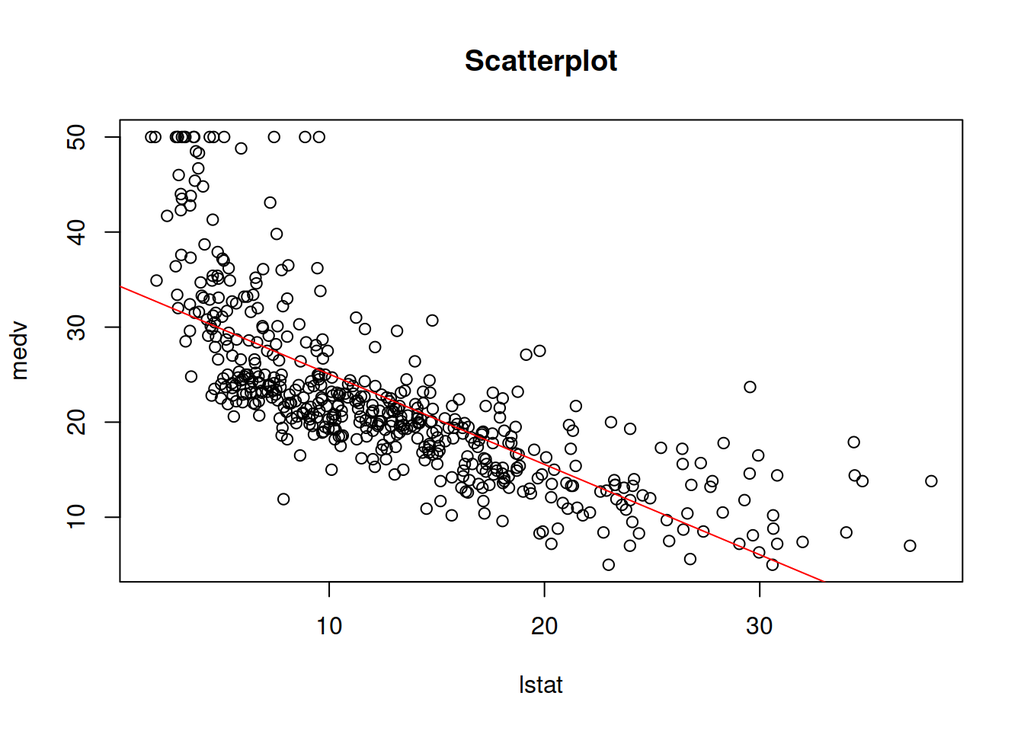

```r
plot(lstat,medv, main = "Scatterplot")
abline(modelo_lineal, col = "red")
```

**e) Realice la regresion utilizando todas las variables independientes.**

```r
#Ver cuales son las variables para guardarlas
summary(Boston)
```

```
##       crim                zn             indus            chas
##  Min.   : 0.00632   Min.   :  0.00   Min.   : 0.46   Min.   :0.00000
##  1st Qu.: 0.08205   1st Qu.:  0.00   1st Qu.: 5.19   1st Qu.:0.00000
##  Median : 0.25651   Median :  0.00   Median : 9.69   Median :0.00000
##  Mean   : 3.61352   Mean   : 11.36   Mean   :11.14   Mean   :0.06917
##  3rd Qu.: 3.67708   3rd Qu.: 12.50   3rd Qu.:18.10   3rd Qu.:0.00000
##  Max.   :88.97620   Max.   :100.00   Max.   :27.74   Max.   :1.00000
##       nox               rm             age              dis
##  Min.   :0.3850   Min.   :3.561   Min.   :  2.90   Min.   : 1.130
##  1st Qu.:0.4490   1st Qu.:5.886   1st Qu.: 45.02   1st Qu.: 2.100
##  Median :0.5380   Median :6.208   Median : 77.50   Median : 3.207
##  Mean   :0.5547   Mean   :6.285   Mean   : 68.57   Mean   : 3.795
##  3rd Qu.:0.6240   3rd Qu.:6.623   3rd Qu.: 94.08   3rd Qu.: 5.188
##  Max.   :0.8710   Max.   :8.780   Max.   :100.00   Max.   :12.127
##       rad              tax           ptratio          black
##  Min.   : 1.000   Min.   :187.0   Min.   :12.60   Min.   :  0.32
##  1st Qu.: 4.000   1st Qu.:279.0   1st Qu.:17.40   1st Qu.:375.38
##  Median : 5.000   Median :330.0   Median :19.05   Median :391.44
##  Mean   : 9.549   Mean   :408.2   Mean   :18.46   Mean   :356.67
##  3rd Qu.:24.000   3rd Qu.:666.0   3rd Qu.:20.20   3rd Qu.:396.23
##  Max.   :24.000   Max.   :711.0   Max.   :22.00   Max.   :396.90
##      lstat            medv
##  Min.   : 1.73   Min.   : 5.00
##  1st Qu.: 6.95   1st Qu.:17.02
##  Median :11.36   Median :21.20
##  Mean   :12.65   Mean   :22.53
##  3rd Qu.:16.95   3rd Qu.:25.00
##  Max.   :37.97   Max.   :50.00
```

```r
medv = Boston$medv
crim = Boston$crim
zn = Boston$zn
indus = Boston$indus
chas = Boston$chas
nox = Boston$nox
rm = Boston$rm
age = Boston$age
dis = Boston$dis
rad = Boston$rad
tax = Boston$tax
ptratio = Boston$ptratio
black = Boston$black
lstat = Boston$lstat
reg <- lm(medv~  crim +  zn +  indus +  chas +  nox +  rm +  age +  dis +  rad +  tax +  ptratio +  black +  lstat)
summary(reg)
```

```
##
## Call:
## lm(formula = medv ~ crim + zn + indus + chas + nox + rm + age +
##     dis + rad + tax + ptratio + black + lstat)
##
## Residuals:
##     Min      1Q  Median      3Q     Max
## -15.595  -2.730  -0.518   1.777  26.199
##
## Coefficients:
##               Estimate Std. Error t value Pr(>|t|)
## (Intercept)  3.646e+01  5.103e+00   7.144 3.28e-12 ***
## crim        -1.080e-01  3.286e-02  -3.287 0.001087 **
## zn           4.642e-02  1.373e-02   3.382 0.000778 ***
## indus        2.056e-02  6.150e-02   0.334 0.738288
## chas         2.687e+00  8.616e-01   3.118 0.001925 **
## nox         -1.777e+01  3.820e+00  -4.651 4.25e-06 ***
## rm           3.810e+00  4.179e-01   9.116  < 2e-16 ***
## age          6.922e-04  1.321e-02   0.052 0.958229
## dis         -1.476e+00  1.995e-01  -7.398 6.01e-13 ***
## rad          3.060e-01  6.635e-02   4.613 5.07e-06 ***
## tax         -1.233e-02  3.760e-03  -3.280 0.001112 **
## ptratio     -9.527e-01  1.308e-01  -7.283 1.31e-12 ***
## black        9.312e-03  2.686e-03   3.467 0.000573 ***
## lstat       -5.248e-01  5.072e-02 -10.347  < 2e-16 ***
## ---
## Signif. codes:  0 '***' 0.001 '**' 0.01 '*' 0.05 '.' 0.1 ' ' 1
##
## Residual standard error: 4.745 on 492 degrees of freedom
## Multiple R-squared:  0.7406, Adjusted R-squared:  0.7338
## F-statistic: 108.1 on 13 and 492 DF,  p-value: < 2.2e-16
```

```r
confint.lm(reg)
```

```
##                     2.5 %        97.5 %
## (Intercept)  26.432226009  46.486750761
## crim         -0.172584412  -0.043438304
## zn            0.019448778   0.073392139
## indus        -0.100267941   0.141385193
## chas          0.993904193   4.379563446
## nox         -25.271633564 -10.261588893
## rm            2.988726773   4.631003640
## age          -0.025262320   0.026646769
## dis          -1.867454981  -1.083678710
## rad           0.175692169   0.436406789
## tax          -0.019723286  -0.004945902
## ptratio      -1.209795296  -0.695699168
## black         0.004034306   0.014589060
## lstat        -0.624403622  -0.425113133
```

**f) Intervalos de confianza y valor esperado con el promedio de las variables independientes. Intervalo de confianza para la prediccion.**

```r
new_dat <- data.frame( crim = mean( crim),  zn = mean( zn),  indus = mean( indus),  chas = mean( chas),  nox = mean( nox),  rm = mean( rm),  age = mean( age),  dis = mean( dis),  rad = mean( rad),  tax = mean( tax),  ptratio = mean( ptratio),  black = mean( black),  lstat = mean( lstat))
predict(reg, new_dat, level=0.95, interval="confidence") #Intervalo de conf
```

```
##        fit      lwr      upr
## 1 22.53281 22.11832 22.94729
```

```r
predict(reg, new_dat, level=0.95, interval="prediction") #Intervalo de conf para la prediccion
```

```
##        fit      lwr      upr
## 1 22.53281 13.20005 31.86556
```

## 5) Se realizan observaciones de dos respuestas sobre tres tratamientos. Los vectores de observacion son:

```r
Tratamiento1 = cbind(rbind(2,9),rbind(3,2),rbind(7,5),rbind(2,1),rbind(7,5))
Tratamiento2 = cbind(rbind(3,2),rbind(2,4),rbind(9,4))
Tratamiento3 = cbind(rbind(1,4),rbind(7,2),rbind(4,9),rbind(3,2))
```

**a) Construya la tabla de one-way MANOVA**

```r
t1Bar = rowMeans(Tratamiento1)
t2Bar = rowMeans(Tratamiento2)
t3Bar = rowMeans(Tratamiento3)
tratamientos = cbind(Tratamiento1,Tratamiento2,Tratamiento3)
tbar = rowMeans(tratamientos)
totalObservations = 12
```

```r
row1=0
row2=0
for (i in tratamientos[1,]) {
  row1 = row1+i^2
}
for (i in tratamientos[2,]) {
  row2 = row2+i^2
}
SSobs = cbind(row1,row2)
SSmean = totalObservations*cbind(tbar[1]^2,tbar[2]^2)
```

```r
row1=0
row2=0
for (i in tratamientos[1,]) {
  row1 = row1+i^2
}
for (i in tratamientos[2,]) {
  row2 = row2+i^2
}
Rrow1 =0
Rrow2 =0
for (k in tratamientos[1,1:5]) {
  Rrow1 = Rrow1+(k-t1Bar[1])^2
}
for (k in tratamientos[1,6:8]) {
  Rrow1 = Rrow1+(k-t2Bar[1])^2
}
for (k in tratamientos[1,9:12]) {
  Rrow1 = Rrow1+(k-t3Bar[1])^2
}
for (k in tratamientos[2,1:5]) {
  Rrow2 = Rrow2+(k-t1Bar[2])^2
}
for (k in tratamientos[2,6:8]) {
  Rrow2 = Rrow2+(k-t2Bar[2])^2
}
for (k in tratamientos[2,9:12]) {
  Rrow2 = Rrow2+(k-t3Bar[2])^2
}
SSobs = cbind(row1,row2)
SSmean = totalObservations*cbind(tbar[1]^2,tbar[2]^2)
SStrt = (5*cbind((t1Bar[1]-tbar[1])^2,(t1Bar[2]-tbar[2])^2))+(3*cbind((t2Bar[1]-tbar[1])^2,(t2Bar[2]-tbar[2])^2))+(4*cbind((t3Bar[1]-tbar[1])^2,(t3Bar[2]-tbar[2])^2))
SSres = cbind(Rrow1,Rrow2)
SStotal = SSobs-SSmean
row1t=0
```

```r
SSobst =(2*9)+(3*2)+(7*5)+(2*1)+(7*5)+(3*2)+(2*4)+(9*4)+(1*4)+(7*2)+(4*9)+(3*2)
SSmeant = totalObservations*tbar[1]*tbar[2]
SStrtt = (5*(t1Bar[1]-tbar[1])*(t1Bar[2]-tbar[2]))+(3*(t2Bar[1]-tbar[1])*(t2Bar[2]-tbar[2]))+(4*(t3Bar[1]-tbar[1])*(t3Bar[2]-tbar[2]))
SSrest = 3.2
SStotalt = SSobst-SSmeant
```

```r
B <- matrix(c(SStrt[1], SStrtt,
              SStrtt, SStrt[2]), ncol = 2, byrow = TRUE)
W <- matrix(c(SSres[1],SSrest,
              SSrest, SSres[2]), ncol = 2, byrow = TRUE)
BW = B+W
B
```

```
##       [,1]  [,2]
## [1,]  1.45 -1.35
## [2,] -1.35  2.30
```

```r
W
```

```
##          [,1]     [,2]
## [1,] 74.21667  3.20000
## [2,]  3.20000 74.61667
```

```r
BW
```

```
##          [,1]     [,2]
## [1,] 75.66667  1.85000
## [2,]  1.85000 76.91667
```

| Source of variation | Sum of square matrix | Degres |
| --- | --- | --- |
| Treatment | B | 2 |
| Residual | W | 9 |
| Total | B+W | 11 |

**b) Evalue el Lambda de Wilk, $\Lambda^*$ y realice una prueba de hipótesis de los efectos de tratamiento.Set $\alpha = 0.05$**

$H_0 = T_1 = T_2 = T_3$ $H_a = T_l = 0 \ \ \ \ l=1,2,3$

```r
g=3
p=2
Lam = det(W)/(det(BW))
prueba = ((totalObservations-g-1)/(g-1))*((1-sqrt(Lam))/(sqrt(Lam)))
prueba
```

```
## [1] 0.1032506
```

```r
f1 = qf(1-0.05,df1=4,df2=16)
f1
```

```
## [1] 3.006917
```

Podemos observas que $0.103<3.006$ es decir que no vamos a rechazar la prueba $H_0$

**c) Repita la prueba considerando que la prueba es grande.Set $\alpha = 0.05$**

```r
prueba2 = -(totalObservations-1-((p+g)/2))*log(Lam)
prueba2
```

```
## [1] 0.4332473
```

```r
chi = qchisq(1-0.05,df=4)
chi
```

```
## [1] 9.487729
```

Debido a que $0.43<9.48$ decimos que no vamos a rechazar la prueba $H_0$, en esta prueba debido a que era una muestra grande utilizamos la distribución chi cuadrado.